# Sales Forecast with Winter-Holts Method

Iryna G Duda

- Since the time when pandemic started, department’s sales appear to be unpredictable. Thus, to better understand the direction of department performance, it makes sense first to explore the sales during the pre-pandemic normal times and find the prior associations.  
  So the purpose of this analysis is to predict sales based on the time series using historical data from 2016 to pre-pandemic period (February, 2020). Further compare predicted values with the actual data and make the determination how applicable Winter-Holts model can be.

### 1.Preparing Data

```r
dataset0 <- read.csv("Data_072020.csv")
headTail(dataset0, 3)
```

|  | Yr | Mo_No | Date | AvgSold | AvgShipTo | AvgWeekly_Inv | TotalUniqSoldTos | TotalUniqShipTos | TotalInv |
| --- | --- | --- | --- | --- | --- | --- | --- | --- | --- |
| 1 | 2020 | 7 | 7/1/2020 | 187 | 278 | 177403.28 | 4864 | 7233 | 4612485.23 |
| 2 | 2020 | 6 | 6/1/2020 | 206 | 298 | 154289.38 | 5153 | 7457 | 3857234.51 |
| 3 | 2020 | 5 | 5/1/2020 | 173 | 236 | 130550.71 | 3821 | 5206 | 2872115.58 |
| ... | ... | ... | NA | ... | ... | ... | ... | ... | ... |
| 52 | 2016 | 4 | 4/1/2016 | 203 | 245 | 114009.71 | 4473 | 5403 | 2508213.51 |
| 53 | 2016 | 3 | 3/1/2016 | 219 | 265 | 121933.76 | 5264 | 6362 | 2926410.14 |
| 54 | 2016 | 2 | 2/1/2016 | 227 | 273 | 130722.16 | 4775 | 5753 | 2745165.31 |
| 55 | 2016 | 1 | 1/1/2016 | 192 | 232 | 111036.55 | 4241 | 5112 | 2442804.13 |

```r
dataset <- data.frame(dataset0)
attach(dataset)
dataset$Yr <- as.factor(Yr)  # changing the class of the fields
dataset$Mo_No <- as.factor(Mo_No)
dataset$Date <- as.Date(dataset$Date, format = "%m/%d/%Y")  #format='%B %d %Y'
head(dataset, 3)
```

|  | Yr | Mo_No | Date | AvgSold | AvgShipTo | AvgWeekly_Inv | TotalUniqSoldTos | TotalUniqShipTos | TotalInv |
| --- | --- | --- | --- | --- | --- | --- | --- | --- | --- |
| 1 | 2020 | 7 | 2020-07-01 | 187 | 278 | 177403.3 | 4864 | 7233 | 4612485 |
| 2 | 2020 | 6 | 2020-06-01 | 206 | 298 | 154289.4 | 5153 | 7457 | 3857235 |
| 3 | 2020 | 5 | 2020-05-01 | 173 | 236 | 130550.7 | 3821 | 5206 | 2872116 |

```r
dataset$AvgWeekly_Inv <- as.numeric(AvgWeekly_Inv)
dataset$TotalInv <- as.numeric(TotalInv)
dataset <- dataset[order(dataset$Date, dataset$Mo_No), ]
attach(dataset)
des(dataset)
```

```
##
##  No. of observations =  55
##   Variable         Class           Description
## 1 Yr               factor
## 2 Mo_No            factor
## 3 Date             Date
## 4 AvgSold          integer
## 5 AvgShipTo        integer
## 6 AvgWeekly_Inv    numeric
## 7 TotalUniqSoldTos integer
## 8 TotalUniqShipTos integer
## 9 TotalInv         numeric
```

```r
head(dataset, 3)
```

|  | Yr | Mo_No | Date | AvgSold | AvgShipTo | AvgWeekly_Inv | TotalUniqSoldTos | TotalUniqShipTos | TotalInv |
| --- | --- | --- | --- | --- | --- | --- | --- | --- | --- |
| 55 | 2016 | 1 | 2016-01-01 | 192 | 232 | 111036.6 | 4241 | 5112 | 2442804 |
| 54 | 2016 | 2 | 2016-02-01 | 227 | 273 | 130722.2 | 4775 | 5753 | 2745165 |
| 53 | 2016 | 3 | 2016-03-01 | 219 | 265 | 121933.8 | 5264 | 6362 | 2926410 |

### 2. Exploring Data

To visualize the data, plots below demonstrate:  
* the relationship between monthly sales and number of customers (locations) served on monthly basis  
* the historical sales year over year  
* the historical count of customers’ locations served year over year

To leave bias aside and evaluate Winter-Holts model performance, sales data, that shows a significant drop due to the pandemic, in 2020, is excluded from the analysis.

Monthly sales year over year is chosen to be a predictor variable and is used further in time series Winter-Holts model.

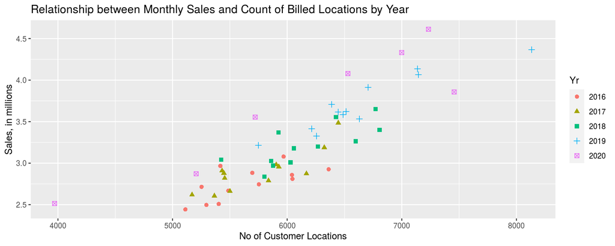

```r
(p1 <- ggplot(dataset, aes(x = TotalUniqShipTos, y = TotalInv/1e+06,
    col = Yr, shape = Yr)) + geom_point(size = 2) + xlab("No of Customer Locations") +
    ylab("Sales, in millions")) + ggtitle("Relationship between Monthly Sales and Count of Billed Locations by Year")
```

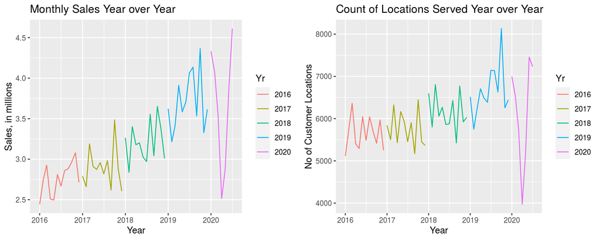

```r
p2 <- ggplot(dataset, aes(x = Date, y = TotalInv/1e+06, col = Yr,
    shape = Yr)) + geom_line(size = 0.5) + xlab("Year") + ylab("Sales, in millions") +
    ggtitle("Monthly Sales Year over Year")
p3 <- ggplot(dataset, aes(x = Date, y = TotalUniqShipTos, col = Yr,
    shape = Yr, show.legend = FALSE)) + geom_line(size = 0.5) +
    xlab("Year") + ylab("No of Customer Locations") + ggtitle("Count of Locations Served Year over Year")
grid.arrange(p2, p3, ncol = 2)
```

### 3. Evaluating ACF and PACF plots

ACF plot shows the significant correlation between current time series and previous lags. Typically, such assumption is appropriate when time series, represented by vertical lines, cross the level of significance (blue dashed line) just as it appears in this case. Also, observation suggests presence of correlation between the last 3 terms, which makes the lag possibly equal to 3. Since time series drop gradually, there is an assumption of non-stationary data behavior. In case of a sudden drop it would point on the stationary data and zero correlation between lags.

PACF also suggests lag equal to 3, because of the first three vertical lines, that are above the 95% of significance level.  
To verify above assumptions, adf.test() is performed. Null hypothesis states that data is non-stationary. Thus p-value is 0.144 which is more then excepted 0.05, we fail to reject null hypothesis and have enough evidence to assume that the data is non-stationary. Adf.test() also recommends lag of 3, which confirms findings from the plots.

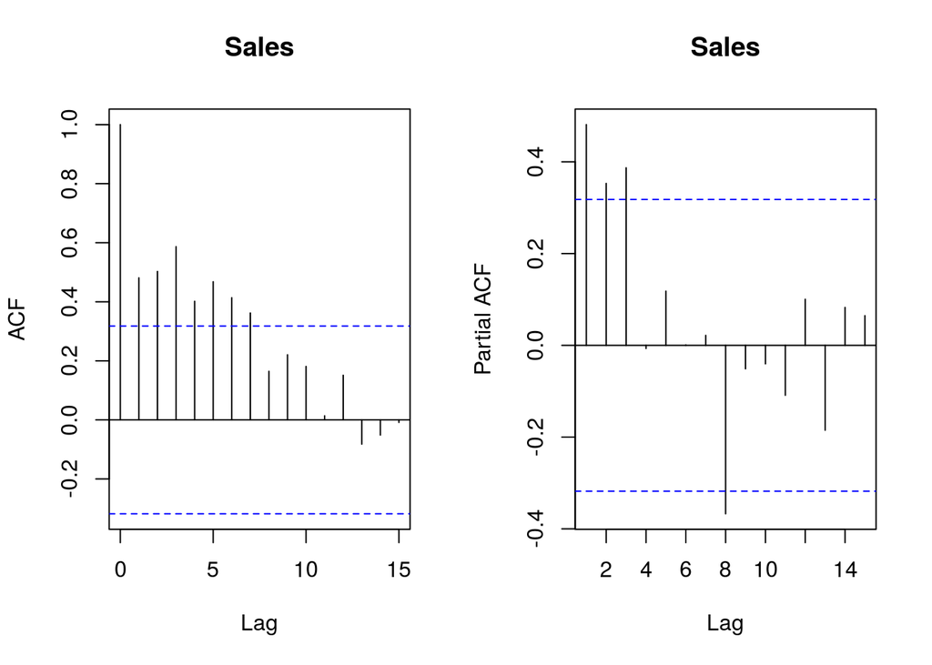

```r
par(mfrow = c(1, 2))
# Modeling time series against Invoice Values per plots ACF
# and PACF
acf(as.ts(dataset[13:50, ]$TotalInv), main = "Sales")  #excluded years 2020 [52:54,] and 2016
pacf(as.ts(dataset[13:50, ]$TotalInv), main = "Sales")
```

```r
par(mfrow = c(1, 1))

tseries::adf.test(TotalInv[13:50], alternative = "stationary")
```

```
##
##  Augmented Dickey-Fuller Test
##
## data:  TotalInv[13:50]
## Dickey-Fuller = -3.0986, Lag order = 3, p-value =
## 0.144
## alternative hypothesis: stationary
```

### 4. Considering Exponential Smoothening with Additive and Multiplicative types

Plot of monthly sales growth shows trend of increase. Thus, need to look at the decomposed data to analyze seasonal behavior.

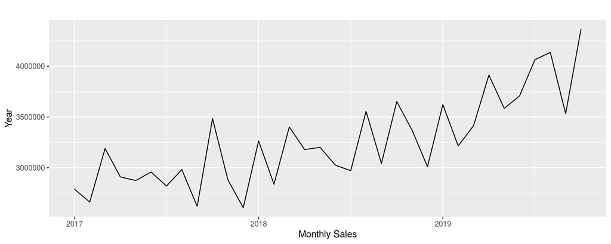

```r
ts_hw <- ts(TotalInv[13:50], frequency = 12, start = c(2017,
    1))
dataset_ts <- window(ts_hw, start = c(2017, 1), end = c(2019,
    10))
autoplot(dataset_ts) + ylab("Year") + xlab("Monthly Sales")
```

```r
decompos_add <- decompose(dataset_ts, type = "additive")
decompos_mult <- decompose(dataset_ts, type = "mult")
(stlRes <- stl(ts_hw, s.window = "periodic"))  # decomposition of time series
```

```
##  Call:
##  stl(x = ts_hw, s.window = "periodic")
##
## Components
##            seasonal   trend    remainder
## Jan 2017  170449.67 2769148 -150097.7901
## Feb 2017 -168967.78 2792383   38073.6880
## Mar 2017  158621.22 2815619  214734.5324
## Apr 2017  125908.82 2839663  -56850.4524
## May 2017  -18673.60 2863708   28740.5554
## Jun 2017  -36841.20 2888527  105696.4097
## Jul 2017  -10208.68 2913347  -83724.6626
## Aug 2017  232365.31 2936905 -187909.4813
## Sep 2017 -290522.66 2960463  -50794.9300
## Oct 2017  447441.94 2980991   56318.7653
## Nov 2017 -227086.82 3001519  105789.2538
## Dec 2017 -382486.23 3024072  -35649.7350
## Jan 2018  170449.67 3046625   46705.5469
## Feb 2018 -168967.78 3071842  -65050.3530
## Mar 2018  158621.22 3097059  145814.6834
## Apr 2018  125908.82 3125165  -72666.4140
## May 2018  -18673.60 3153271   66737.7011
## Jun 2018  -36841.20 3184474 -122491.4719
## Jul 2018  -10208.68 3215677 -234416.3915
## Aug 2018  232365.31 3246508   76586.3385
## Sep 2018 -290522.66 3277338   54805.5784
## Oct 2018  447441.94 3315385 -110949.7050
## Nov 2018 -227086.82 3353431  242310.8548
## Dec 2018 -382486.23 3406602  -14858.2358
## Jan 2019  170449.67 3459772   -8392.1857
## Feb 2019 -168967.78 3515815 -131989.5207
## Mar 2019  158621.22 3571857 -316571.1194
## Apr 2019  125908.82 3617023  169683.5960
## May 2019  -18673.60 3662189  -59123.3560
## Jun 2019  -36841.20 3709568   35169.1976
## Jul 2019  -10208.68 3756946  318534.3247
## Aug 2019  232365.31 3810939   92635.7518
## Sep 2019 -290522.66 3864931  -41778.2711
## Oct 2019  447441.94 3918256     715.3356
## Nov 2019 -227086.82 3971581 -418164.3644
## Dec 2019 -382486.23 4023154  -24785.3955
## Jan 2020  170449.67 4074726   86700.7242
## Feb 2020 -168967.78 4125864  122264.7555
```

Plotted decomposed data look very similar:

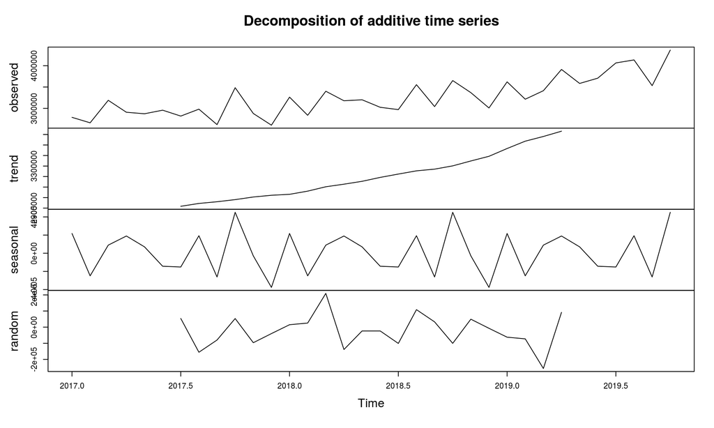

```r
plot(decompos_add)
```

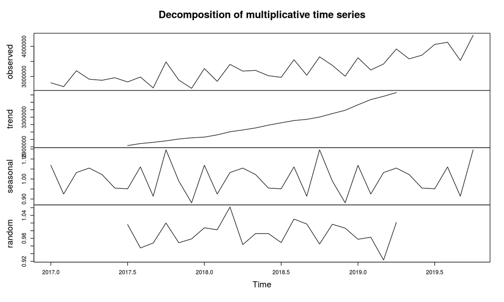

```r
plot(decompos_mult)
```

### 5. Using the Winter-Holts method to predict sales

Side by side forecasts for both “additive” and “multiplicative” model types are demonstrated below.

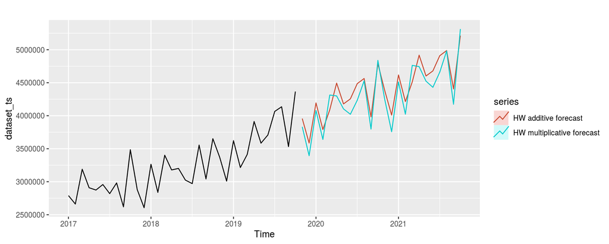

```r
fit1 <- hw(dataset_ts, seasonal = "additive")
fit2 <- hw(dataset_ts, seasonal = "multiplicative")
autoplot(dataset_ts) + autolayer(fit1, series = "HW additive forecast",
    PI = FALSE) + autolayer(fit2, series = "HW multiplicative forecast",
    PI = FALSE)
```

Earlier decomposed plots showed an increase in trend and steady seasonality. This suggests that appropriate seasonal type would be an “additive”. Thus, the fitted values (red line) and forecast values (blue line) are compared to the actual values (black line).

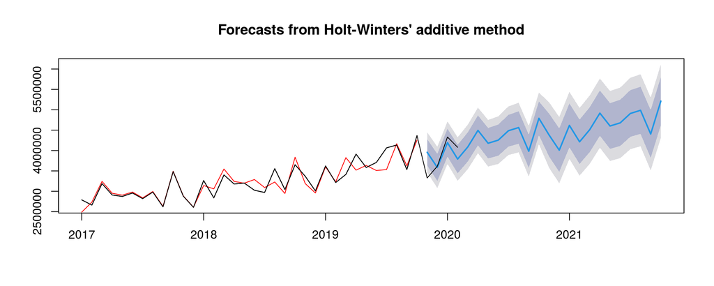

```r
plot(forecast(fit1, 12))

lines(fitted(fit1), col = "red")
lines(ts_hw, col = "black")
```

```r
fit1$model
```

```
## Holt-Winters' additive method
##
## Call:
##  hw(y = dataset_ts, seasonal = "additive")
##
##   Smoothing parameters:
##     alpha = 0.2387
##     beta  = 7e-04
##     gamma = 0.7613
##
##   Initial states:
##     l = 2645165.6546
##     b = 34975.7468
##     s = -458936.9 -149675.7 489829.3 -340800.7 56390.37 -70581.99
##            102363.1 53731.28 123653.7 438883.1 -53626.87 -191228.8
##
##   sigma:  250962
##
##       AIC      AICc       BIC
##  977.7205 1015.9705 1003.6686
```

### 6. Sales Forecast Values Versus Actual Data:

```r
(f <- forecast::forecast(fit1, 12))
```

```
##          Point Forecast   Lo 80   Hi 80   Lo 95   Hi 95
## Nov 2019        3957036 3635416 4278657 3465160 4448913
## Dec 2019        3586025 3255320 3916730 3080256 4091795
## Jan 2020        4193621 3854025 4533218 3674253 4712990
## Feb 2020        3790994 3442683 4139305 3258298 4323690
## Mar 2020        4088753 3731892 4445614 3542981 4634525
## Apr 2020        4494286 4129027 4859544 3935671 5052901
## May 2020        4178714 3805200 4552228 3607474 4749954
## Jun 2020        4255486 3873850 4637123 3671824 4839149
## Jul 2020        4486029 4096394 4875664 3890134 5081924
## Aug 2020        4563989 4166472 4961505 3956040 5171937
## Sep 2020        3982293 3577005 4387581 3362459 4602128
## Oct 2020        4789856 4376900 5202812 4158294 5421418
## Nov 2020        4380480 3855406 4905553 3577449 5183511
## Dec 2020        4009468 3478387 4540550 3197249 4821688
## Jan 2021        4617065 4080009 5154120 3795709 5438421
## Feb 2021        4214437 3671440 4757434 3383995 5044879
## Mar 2021        4512196 3963289 5061102 3672716 5351676
## Apr 2021        4917729 4362944 5472514 4069258 5766200
## May 2021        4602157 4041522 5162792 3744740 5459574
## Jun 2021        4678930 4112474 5245385 3812610 5545249
## Jul 2021        4909472 4337223 5481721 4034293 5784652
## Aug 2021        4987432 4409416 5565448 4103433 5871431
## Sep 2021        4405737 3821980 4989493 3512958 5298515
## Oct 2021        5213299 4623827 5802772 4311779 6114820
```

```r
actuals <- filter(dataset0, dataset0$Yr > 2019)
actuals <- actuals[, c(1, 2, 3, 9)]
actuals <- actuals[order(actuals$Mo_No, decreasing = TRUE), ]
actuals
```

|  | Yr | Mo_No | Date | TotalInv |
| --- | --- | --- | --- | --- |
| 1 | 2020 | 7 | 7/1/2020 | 4612485 |
| 2 | 2020 | 6 | 6/1/2020 | 3857235 |
| 3 | 2020 | 5 | 5/1/2020 | 2872116 |
| 4 | 2020 | 4 | 4/1/2020 | 2514233 |
| 5 | 2020 | 3 | 3/1/2020 | 3554428 |
| 6 | 2020 | 2 | 2/1/2020 | 4079161 |
| 7 | 2020 | 1 | 1/1/2020 | 4331877 |

```r
comp <- cbind(yr = actuals$Yr, month = order(actuals$Mo_No, decreasing = TRUE),
    predicted = f$mean[3:9], actuals = actuals$TotalInv, error_per = (f$mean[3:9] -
        actuals$TotalInv)/actuals$TotalInv * 100)
```

```r
library(lubridate)
comp <- data.frame(comp)
colnames(comp) <- c("Year", "Month", "Predicted", "Actuals",
    "Error in %")
comp
```

| Year | Month | Predicted | Actuals | Error in % |
| --- | --- | --- | --- | --- |
| 2020 | 1 | 4193621 | 4612485 | -9.081086 |
| 2020 | 2 | 3790994 | 3857235 | -1.717305 |
| 2020 | 3 | 4088753 | 2872116 | 42.360315 |
| 2020 | 4 | 4494286 | 2514233 | 78.753740 |
| 2020 | 5 | 4178714 | 3554428 | 17.563630 |
| 2020 | 6 | 4255486 | 4079161 | 4.322593 |
| 2020 | 7 | 4486029 | 4331877 | 3.558563 |

```r
# class(comp)

comp$Year <- as.factor(comp$Year)
comp$Month <- as.factor(comp$Month)
comp$Predicted <- as.numeric(comp$Predicted)
comp$Actuals <- as.numeric(comp$Actuals)
des(comp)
```

```
##
##  No. of observations =  7
##   Variable      Class           Description
## 1 Year          factor
## 2 Month         factor
## 3 Predicted     numeric
## 4 Actuals       numeric
## 5 Error in %    numeric
```

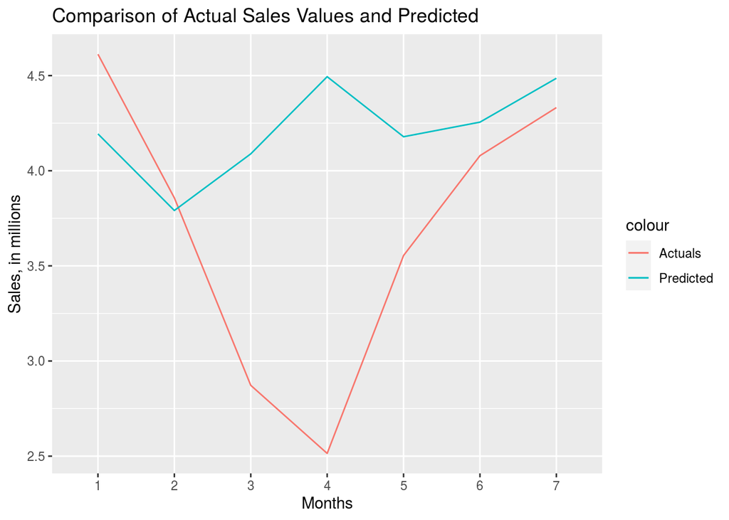

```r
# comp<-fortify(comp)
ggplot(comp, aes(x = Month, group = 1)) + geom_line(aes(y = Actuals/1e+06,
    col = "Actuals")) + geom_line(aes(y = Predicted/1e+06, col = "Predicted")) +
    xlab("Months") + ylab("Sales, in millions") + ggtitle("Comparison of Actual Sales Values and Predicted")
```